# COVID-19 Report: Comparing the US and Canada

Luke Shi

2025-06-23

# **Abstract**

COVID-19 is a virus that had enormous global impact. Today, a comparison between the US and Canada will be performed to observe the differences between the cases and deaths caused by COVID-19. It will be interesting to see the differences between two neighboring countries that are quite similar in government, culture, and geographic location. Through data visualizations it appears that Canada has a lower rate of cases and deaths among its population.

# **Importing Data**

## Loading the CSV Data from GitHub

The COVID19 data set is loaded from a GitHub repository. Four main CSV files are initially loaded and they contain data on the total number of global cases, the total number of global deaths, the total number of US cases, and the total number of US deaths. The URLs required are generated through a concatenation between the first part of the URL and the last part, which is the part that varies. Lastly, a UID_ISO_FIPS_LookUp_Table CSV file is loaded which will be used later.

```r
url_in <- "https://raw.githubusercontent.com/CSSEGISandData/COVID-19/master/csse_covid_19_data/csse_covid_19_time_series/"
file_names <- c("time_series_covid19_confirmed_global.csv",
                "time_series_covid19_deaths_global.csv",
                "time_series_covid19_confirmed_US.csv",
                "time_series_covid19_deaths_US.csv")
urls <- str_c(url_in, file_names)
uid_lookup_url <- "https://raw.githubusercontent.com/CSSEGISandData/COVID-19/master/csse_covid_19_data/UID_ISO_FIPS_LookUp_Table.csv"
```

## Creating the Initial Data Tables

After reading the CSV files, four initial tables are created called: “global_cases”, “global_deaths”, “US_cases”, “US_deaths”. The uid_lookup_url will also be read in for later and called “uid”.

```r
global_cases <- read_csv(urls[1])
global_deaths <- read_csv(urls[2])
US_cases <- read_csv(urls[3])
US_deaths <- read_csv(urls[4])
uid <- read_csv(uid_lookup_url)
```

# **Data Pre-processing**

## Viewing the global_cases Data 1

The global_cases table is inspected to view how the data looks like. Notably, it appears that there is a column for “Lat” and “Long” and then a column afterwards for every date.

```r
global_cases
```

```
## # A tibble: 289 × 1,147
##    `Province/State`  `Country/Region`   Lat   Long `1/22/20` `1/23/20` `1/24/20`
##    <chr>             <chr>            <dbl>  <dbl>     <dbl>     <dbl>     <dbl>
##  1 <NA>              Afghanistan       33.9  67.7          0         0         0
##  2 <NA>              Albania           41.2  20.2          0         0         0
##  3 <NA>              Algeria           28.0   1.66         0         0         0
##  4 <NA>              Andorra           42.5   1.52         0         0         0
##  5 <NA>              Angola           -11.2  17.9          0         0         0
##  6 <NA>              Antarctica       -71.9  23.3          0         0         0
##  7 <NA>              Antigua and Bar…  17.1 -61.8          0         0         0
##  8 <NA>              Argentina        -38.4 -63.6          0         0         0
##  9 <NA>              Armenia           40.1  45.0          0         0         0
## 10 Australian Capit… Australia        -35.5 149.           0         0         0
## # ℹ 279 more rows
## # ℹ 1,140 more variables: `1/25/20` <dbl>, `1/26/20` <dbl>, `1/27/20` <dbl>,
## #   `1/28/20` <dbl>, `1/29/20` <dbl>, `1/30/20` <dbl>, `1/31/20` <dbl>,
## #   `2/1/20` <dbl>, `2/2/20` <dbl>, `2/3/20` <dbl>, `2/4/20` <dbl>,
## #   `2/5/20` <dbl>, `2/6/20` <dbl>, `2/7/20` <dbl>, `2/8/20` <dbl>,
## #   `2/9/20` <dbl>, `2/10/20` <dbl>, `2/11/20` <dbl>, `2/12/20` <dbl>,
## #   `2/13/20` <dbl>, `2/14/20` <dbl>, `2/15/20` <dbl>, `2/16/20` <dbl>, …
```

## Tidying Up the global_cases Data

Since the “Lat” and “Long” columns will not be used in future analysis (expected to represent the latitude and longitude of the Country/Region column), those columns will be removed. Also the dates columns and the number of cases under each column will become two columns in total. One “date” column which will list all the dates for a Country/Region and a “cases” column which will list the total number of cases per date.

```r
global_cases <- global_cases %>%
  pivot_longer(cols = -c(`Province/State`,
                         `Country/Region`, Lat, Long),
               names_to = "date",
               values_to = "cases") %>%
  select(-c(Lat,Long))
```

## Viewing the global_cases Data 2

Now the global_cases data is viewed and the data should look more tidy.

```r
global_cases
```

```
## # A tibble: 330,327 × 4
##    `Province/State` `Country/Region` date    cases
##    <chr>            <chr>            <chr>   <dbl>
##  1 <NA>             Afghanistan      1/22/20     0
##  2 <NA>             Afghanistan      1/23/20     0
##  3 <NA>             Afghanistan      1/24/20     0
##  4 <NA>             Afghanistan      1/25/20     0
##  5 <NA>             Afghanistan      1/26/20     0
##  6 <NA>             Afghanistan      1/27/20     0
##  7 <NA>             Afghanistan      1/28/20     0
##  8 <NA>             Afghanistan      1/29/20     0
##  9 <NA>             Afghanistan      1/30/20     0
## 10 <NA>             Afghanistan      1/31/20     0
## # ℹ 330,317 more rows
```

## Viewing the global_deaths Data 1

The global_deaths table will also be viewed to get an idea of how the data looks like.

```r
global_deaths
```

```
## # A tibble: 289 × 1,147
##    `Province/State`  `Country/Region`   Lat   Long `1/22/20` `1/23/20` `1/24/20`
##    <chr>             <chr>            <dbl>  <dbl>     <dbl>     <dbl>     <dbl>
##  1 <NA>              Afghanistan       33.9  67.7          0         0         0
##  2 <NA>              Albania           41.2  20.2          0         0         0
##  3 <NA>              Algeria           28.0   1.66         0         0         0
##  4 <NA>              Andorra           42.5   1.52         0         0         0
##  5 <NA>              Angola           -11.2  17.9          0         0         0
##  6 <NA>              Antarctica       -71.9  23.3          0         0         0
##  7 <NA>              Antigua and Bar…  17.1 -61.8          0         0         0
##  8 <NA>              Argentina        -38.4 -63.6          0         0         0
##  9 <NA>              Armenia           40.1  45.0          0         0         0
## 10 Australian Capit… Australia        -35.5 149.           0         0         0
## # ℹ 279 more rows
## # ℹ 1,140 more variables: `1/25/20` <dbl>, `1/26/20` <dbl>, `1/27/20` <dbl>,
## #   `1/28/20` <dbl>, `1/29/20` <dbl>, `1/30/20` <dbl>, `1/31/20` <dbl>,
## #   `2/1/20` <dbl>, `2/2/20` <dbl>, `2/3/20` <dbl>, `2/4/20` <dbl>,
## #   `2/5/20` <dbl>, `2/6/20` <dbl>, `2/7/20` <dbl>, `2/8/20` <dbl>,
## #   `2/9/20` <dbl>, `2/10/20` <dbl>, `2/11/20` <dbl>, `2/12/20` <dbl>,
## #   `2/13/20` <dbl>, `2/14/20` <dbl>, `2/15/20` <dbl>, `2/16/20` <dbl>, …
```

## Tidying Up the global_deaths Data

The same code that was applied to the global_cases data will now be similarly applied to the global_deaths data.

```r
global_deaths <- global_deaths %>%
  pivot_longer(cols = -c(`Province/State`,
                         `Country/Region`, Lat, Long),
               names_to = "date",
               values_to = "deaths") %>%
  select(-c(Lat,Long))
```

## Viewing the global_deaths Data 2

Similar to the global_cases data, the global_deaths data should look more tidy now.

```r
global_deaths
```

```
## # A tibble: 330,327 × 4
##    `Province/State` `Country/Region` date    deaths
##    <chr>            <chr>            <chr>    <dbl>
##  1 <NA>             Afghanistan      1/22/20      0
##  2 <NA>             Afghanistan      1/23/20      0
##  3 <NA>             Afghanistan      1/24/20      0
##  4 <NA>             Afghanistan      1/25/20      0
##  5 <NA>             Afghanistan      1/26/20      0
##  6 <NA>             Afghanistan      1/27/20      0
##  7 <NA>             Afghanistan      1/28/20      0
##  8 <NA>             Afghanistan      1/29/20      0
##  9 <NA>             Afghanistan      1/30/20      0
## 10 <NA>             Afghanistan      1/31/20      0
## # ℹ 330,317 more rows
```

## Combining global_cases and global_deaths into one set called “global”

After tidying up the global_cases and global_deaths data they will be combined (full joined) into the “global” data set. Also, the date column will be changed into a date object since it was not one before.

```r
global <- global_cases %>%
  full_join(global_deaths) %>%
  rename(Country_Region = `Country/Region`,
         Province_State = `Province/State`) %>%
  mutate(date = mdy(date))
```

## Viewing the global Data 1

Let’s view the global data now to see how it looks like. There should now be a cases and deaths column.

```r
global
```

```
## # A tibble: 330,327 × 5
##    Province_State Country_Region date       cases deaths
##    <chr>          <chr>          <date>     <dbl>  <dbl>
##  1 <NA>           Afghanistan    2020-01-22     0      0
##  2 <NA>           Afghanistan    2020-01-23     0      0
##  3 <NA>           Afghanistan    2020-01-24     0      0
##  4 <NA>           Afghanistan    2020-01-25     0      0
##  5 <NA>           Afghanistan    2020-01-26     0      0
##  6 <NA>           Afghanistan    2020-01-27     0      0
##  7 <NA>           Afghanistan    2020-01-28     0      0
##  8 <NA>           Afghanistan    2020-01-29     0      0
##  9 <NA>           Afghanistan    2020-01-30     0      0
## 10 <NA>           Afghanistan    2020-01-31     0      0
## # ℹ 330,317 more rows
```

## Viewing a Summary of global Data

Let’s view a summary of the global data.

```r
summary(global)
```

```
##  Province_State     Country_Region          date                cases
##  Length:330327      Length:330327      Min.   :2020-01-22   Min.   :        0
##  Class :character   Class :character   1st Qu.:2020-11-02   1st Qu.:      680
##  Mode  :character   Mode  :character   Median :2021-08-15   Median :    14429
##                                        Mean   :2021-08-15   Mean   :   959384
##                                        3rd Qu.:2022-05-28   3rd Qu.:   228517
##                                        Max.   :2023-03-09   Max.   :103802702
##      deaths
##  Min.   :      0
##  1st Qu.:      3
##  Median :    150
##  Mean   :  13380
##  3rd Qu.:   3032
##  Max.   :1123836
```

## Removing Rows with 0 Cases

It looks like there are a lot of rows where there are 0 cases. Let’s remove the rows where cases = 0 and then check the summary again to make sure they are removed.

```r
global <- global %>% filter(cases > 0)
summary(global)
```

```
##  Province_State     Country_Region          date                cases
##  Length:306827      Length:306827      Min.   :2020-01-22   Min.   :        1
##  Class :character   Class :character   1st Qu.:2020-12-12   1st Qu.:     1316
##  Mode  :character   Mode  :character   Median :2021-09-16   Median :    20365
##                                        Mean   :2021-09-11   Mean   :  1032863
##                                        3rd Qu.:2022-06-15   3rd Qu.:   271281
##                                        Max.   :2023-03-09   Max.   :103802702
##      deaths
##  Min.   :      0
##  1st Qu.:      7
##  Median :    214
##  Mean   :  14405
##  3rd Qu.:   3665
##  Max.   :1123836
```

## Viewing the US_cases Data 1

Let’s view the US_cases data to see how it looks like.

```r
US_cases
```

```
## # A tibble: 3,342 × 1,154
##         UID iso2  iso3  code3  FIPS Admin2   Province_State Country_Region   Lat
##       <dbl> <chr> <chr> <dbl> <dbl> <chr>    <chr>          <chr>          <dbl>
##  1 84001001 US    USA     840  1001 Autauga  Alabama        US              32.5
##  2 84001003 US    USA     840  1003 Baldwin  Alabama        US              30.7
##  3 84001005 US    USA     840  1005 Barbour  Alabama        US              31.9
##  4 84001007 US    USA     840  1007 Bibb     Alabama        US              33.0
##  5 84001009 US    USA     840  1009 Blount   Alabama        US              34.0
##  6 84001011 US    USA     840  1011 Bullock  Alabama        US              32.1
##  7 84001013 US    USA     840  1013 Butler   Alabama        US              31.8
##  8 84001015 US    USA     840  1015 Calhoun  Alabama        US              33.8
##  9 84001017 US    USA     840  1017 Chambers Alabama        US              32.9
## 10 84001019 US    USA     840  1019 Cherokee Alabama        US              34.2
## # ℹ 3,332 more rows
## # ℹ 1,145 more variables: Long_ <dbl>, Combined_Key <chr>, `1/22/20` <dbl>,
## #   `1/23/20` <dbl>, `1/24/20` <dbl>, `1/25/20` <dbl>, `1/26/20` <dbl>,
## #   `1/27/20` <dbl>, `1/28/20` <dbl>, `1/29/20` <dbl>, `1/30/20` <dbl>,
## #   `1/31/20` <dbl>, `2/1/20` <dbl>, `2/2/20` <dbl>, `2/3/20` <dbl>,
## #   `2/4/20` <dbl>, `2/5/20` <dbl>, `2/6/20` <dbl>, `2/7/20` <dbl>,
## #   `2/8/20` <dbl>, `2/9/20` <dbl>, `2/10/20` <dbl>, `2/11/20` <dbl>, …
```

## Tidying Up the US_cases Data

There seems to be some odd codes in the first 5 columns that will not be used. Similar to the global_cases data, the dates and cases will be pivoted and the “Lat” and “Long” columns will be removed. The dates column is also a character vector which will need to be converted into a date vector.

```r
US_cases <- US_cases %>%
  pivot_longer(cols = -(UID:Combined_Key),
               names_to = "date",
               values_to = "cases") %>%
  select(Admin2:cases) %>%
  mutate(date = mdy(date)) %>%
  select(-c(Lat, Long_))
```

## Viewing the US_cases Data 2

Let’s view the US_cases data and confirm that all the changes went through properly.

```r
US_cases
```

```
## # A tibble: 3,819,906 × 6
##    Admin2  Province_State Country_Region Combined_Key         date       cases
##    <chr>   <chr>          <chr>          <chr>                <date>     <dbl>
##  1 Autauga Alabama        US             Autauga, Alabama, US 2020-01-22     0
##  2 Autauga Alabama        US             Autauga, Alabama, US 2020-01-23     0
##  3 Autauga Alabama        US             Autauga, Alabama, US 2020-01-24     0
##  4 Autauga Alabama        US             Autauga, Alabama, US 2020-01-25     0
##  5 Autauga Alabama        US             Autauga, Alabama, US 2020-01-26     0
##  6 Autauga Alabama        US             Autauga, Alabama, US 2020-01-27     0
##  7 Autauga Alabama        US             Autauga, Alabama, US 2020-01-28     0
##  8 Autauga Alabama        US             Autauga, Alabama, US 2020-01-29     0
##  9 Autauga Alabama        US             Autauga, Alabama, US 2020-01-30     0
## 10 Autauga Alabama        US             Autauga, Alabama, US 2020-01-31     0
## # ℹ 3,819,896 more rows
```

## Viewing the US_deaths Data 1

Now let’s view the US_deaths data to see if there are any differences in format compared to the US_cases data. If they are the same, then the US_deaths data will be tidied similar to how the US_cases data was tidied.

```r
US_deaths
```

```
## # A tibble: 3,342 × 1,155
##         UID iso2  iso3  code3  FIPS Admin2   Province_State Country_Region   Lat
##       <dbl> <chr> <chr> <dbl> <dbl> <chr>    <chr>          <chr>          <dbl>
##  1 84001001 US    USA     840  1001 Autauga  Alabama        US              32.5
##  2 84001003 US    USA     840  1003 Baldwin  Alabama        US              30.7
##  3 84001005 US    USA     840  1005 Barbour  Alabama        US              31.9
##  4 84001007 US    USA     840  1007 Bibb     Alabama        US              33.0
##  5 84001009 US    USA     840  1009 Blount   Alabama        US              34.0
##  6 84001011 US    USA     840  1011 Bullock  Alabama        US              32.1
##  7 84001013 US    USA     840  1013 Butler   Alabama        US              31.8
##  8 84001015 US    USA     840  1015 Calhoun  Alabama        US              33.8
##  9 84001017 US    USA     840  1017 Chambers Alabama        US              32.9
## 10 84001019 US    USA     840  1019 Cherokee Alabama        US              34.2
## # ℹ 3,332 more rows
## # ℹ 1,146 more variables: Long_ <dbl>, Combined_Key <chr>, Population <dbl>,
## #   `1/22/20` <dbl>, `1/23/20` <dbl>, `1/24/20` <dbl>, `1/25/20` <dbl>,
## #   `1/26/20` <dbl>, `1/27/20` <dbl>, `1/28/20` <dbl>, `1/29/20` <dbl>,
## #   `1/30/20` <dbl>, `1/31/20` <dbl>, `2/1/20` <dbl>, `2/2/20` <dbl>,
## #   `2/3/20` <dbl>, `2/4/20` <dbl>, `2/5/20` <dbl>, `2/6/20` <dbl>,
## #   `2/7/20` <dbl>, `2/8/20` <dbl>, `2/9/20` <dbl>, `2/10/20` <dbl>, …
```

## Tidying Up the US_deaths data

Since, the US_deaths data appears to have similar columns as the original US_cases data, let’s tidy it up in a similar way. Ultimately, there should be a date and cases column and the “Lat”, “Long”, and any other irrelevant columns should be removed. The date column should also be a date object.

```r
US_deaths <- US_deaths %>%
  pivot_longer(cols = -(UID:Population),
               names_to = "date",
               values_to = "deaths") %>%
  select(Admin2:deaths) %>%
  mutate(date = mdy(date)) %>%
  select(-c(Lat, Long_))
```

## Viewing the US_deaths Data 2

Now let’s look at the US_deaths data. Interestingly, there is a column for population data which isn’t present in the US_cases data.

```r
US_deaths
```

```
## # A tibble: 3,819,906 × 7
##    Admin2  Province_State Country_Region Combined_Key      Population date
##    <chr>   <chr>          <chr>          <chr>                  <dbl> <date>
##  1 Autauga Alabama        US             Autauga, Alabama…      55869 2020-01-22
##  2 Autauga Alabama        US             Autauga, Alabama…      55869 2020-01-23
##  3 Autauga Alabama        US             Autauga, Alabama…      55869 2020-01-24
##  4 Autauga Alabama        US             Autauga, Alabama…      55869 2020-01-25
##  5 Autauga Alabama        US             Autauga, Alabama…      55869 2020-01-26
##  6 Autauga Alabama        US             Autauga, Alabama…      55869 2020-01-27
##  7 Autauga Alabama        US             Autauga, Alabama…      55869 2020-01-28
##  8 Autauga Alabama        US             Autauga, Alabama…      55869 2020-01-29
##  9 Autauga Alabama        US             Autauga, Alabama…      55869 2020-01-30
## 10 Autauga Alabama        US             Autauga, Alabama…      55869 2020-01-31
## # ℹ 3,819,896 more rows
## # ℹ 1 more variable: deaths <dbl>
```

## Full-Joining the US Data

Since the US_cases data doesn’t have a population column, it will be full-joined with the US_deaths data.

```r
US <- US_cases %>%
  full_join(US_deaths)
```

## Viewing the US Data

Now the US data will be viewed to ensure the transformation was performed.

```r
US
```

```
## # A tibble: 3,819,906 × 8
##    Admin2 Province_State Country_Region Combined_Key date       cases Population
##    <chr>  <chr>          <chr>          <chr>        <date>     <dbl>      <dbl>
##  1 Autau… Alabama        US             Autauga, Al… 2020-01-22     0      55869
##  2 Autau… Alabama        US             Autauga, Al… 2020-01-23     0      55869
##  3 Autau… Alabama        US             Autauga, Al… 2020-01-24     0      55869
##  4 Autau… Alabama        US             Autauga, Al… 2020-01-25     0      55869
##  5 Autau… Alabama        US             Autauga, Al… 2020-01-26     0      55869
##  6 Autau… Alabama        US             Autauga, Al… 2020-01-27     0      55869
##  7 Autau… Alabama        US             Autauga, Al… 2020-01-28     0      55869
##  8 Autau… Alabama        US             Autauga, Al… 2020-01-29     0      55869
##  9 Autau… Alabama        US             Autauga, Al… 2020-01-30     0      55869
## 10 Autau… Alabama        US             Autauga, Al… 2020-01-31     0      55869
## # ℹ 3,819,896 more rows
## # ℹ 1 more variable: deaths <dbl>
```

## Viewing the uid Data 1

The uid data is viewed to see what information is present. In order to do any population analysis with the global data, population data is required.

```r
uid
```

```
## # A tibble: 4,321 × 12
##      UID iso2  iso3  code3 FIPS  Admin2 Province_State Country_Region        Lat
##    <dbl> <chr> <chr> <dbl> <chr> <chr>  <chr>          <chr>               <dbl>
##  1     4 AF    AFG       4 <NA>  <NA>   <NA>           Afghanistan          33.9
##  2     8 AL    ALB       8 <NA>  <NA>   <NA>           Albania              41.2
##  3    10 AQ    ATA      10 <NA>  <NA>   <NA>           Antarctica          -71.9
##  4    12 DZ    DZA      12 <NA>  <NA>   <NA>           Algeria              28.0
##  5    20 AD    AND      20 <NA>  <NA>   <NA>           Andorra              42.5
##  6    24 AO    AGO      24 <NA>  <NA>   <NA>           Angola              -11.2
##  7    28 AG    ATG      28 <NA>  <NA>   <NA>           Antigua and Barbuda  17.1
##  8    32 AR    ARG      32 <NA>  <NA>   <NA>           Argentina           -38.4
##  9    51 AM    ARM      51 <NA>  <NA>   <NA>           Armenia              40.1
## 10    40 AT    AUT      40 <NA>  <NA>   <NA>           Austria              47.5
## # ℹ 4,311 more rows
## # ℹ 3 more variables: Long_ <dbl>, Combined_Key <chr>, Population <dbl>
```

## Tidying up the uid Data

It appears the uid data does have population data. Since the population data is needed, it will be selected. The Province_State and Country_Regions will also be selected since they are needed to join the uid data with the global data.

```r
uid <- uid %>% select(Province_State, Country_Region, Population)
```

## Creating a Combined Key for the Global Data

Before adding the population data into the global data, the Province_State and Country_Region columns in global will be used and combined to create a new column called “Combined_Key”. The Province_State and Country_Region columns will still exist.

```r
global <- global %>%
  unite("Combined_Key",
        c(Province_State, Country_Region),
        sep = ", ",
        na.rm = TRUE,
        remove = FALSE)
```

## Viewing the global Data 2

Now the global data is viewed to check that the new Combined_Key column is present.

```r
global
```

```
## # A tibble: 306,827 × 6
##    Combined_Key Province_State Country_Region date       cases deaths
##    <chr>        <chr>          <chr>          <date>     <dbl>  <dbl>
##  1 Afghanistan  <NA>           Afghanistan    2020-02-24     5      0
##  2 Afghanistan  <NA>           Afghanistan    2020-02-25     5      0
##  3 Afghanistan  <NA>           Afghanistan    2020-02-26     5      0
##  4 Afghanistan  <NA>           Afghanistan    2020-02-27     5      0
##  5 Afghanistan  <NA>           Afghanistan    2020-02-28     5      0
##  6 Afghanistan  <NA>           Afghanistan    2020-02-29     5      0
##  7 Afghanistan  <NA>           Afghanistan    2020-03-01     5      0
##  8 Afghanistan  <NA>           Afghanistan    2020-03-02     5      0
##  9 Afghanistan  <NA>           Afghanistan    2020-03-03     5      0
## 10 Afghanistan  <NA>           Afghanistan    2020-03-04     5      0
## # ℹ 306,817 more rows
```

## Adding a Population Column to the global Data

Now a left-join will be performed on the global data with the uid data to add the population data in. The global data should have a new population column after the join.

```r
global <- global %>%
  left_join(uid, by = c("Province_State", "Country_Region")) %>%
  select(Province_State, Country_Region, date,
         cases, deaths, Population, Combined_Key)
```

## Viewing the global Data 3

Now the global data is viewed the ensure the transformation was performed.

```r
global
```

```
## # A tibble: 306,827 × 7
##    Province_State Country_Region date       cases deaths Population Combined_Key
##    <chr>          <chr>          <date>     <dbl>  <dbl>      <dbl> <chr>
##  1 <NA>           Afghanistan    2020-02-24     5      0   38928341 Afghanistan
##  2 <NA>           Afghanistan    2020-02-25     5      0   38928341 Afghanistan
##  3 <NA>           Afghanistan    2020-02-26     5      0   38928341 Afghanistan
##  4 <NA>           Afghanistan    2020-02-27     5      0   38928341 Afghanistan
##  5 <NA>           Afghanistan    2020-02-28     5      0   38928341 Afghanistan
##  6 <NA>           Afghanistan    2020-02-29     5      0   38928341 Afghanistan
##  7 <NA>           Afghanistan    2020-03-01     5      0   38928341 Afghanistan
##  8 <NA>           Afghanistan    2020-03-02     5      0   38928341 Afghanistan
##  9 <NA>           Afghanistan    2020-03-03     5      0   38928341 Afghanistan
## 10 <NA>           Afghanistan    2020-03-04     5      0   38928341 Afghanistan
## # ℹ 306,817 more rows
```

# **Data Visualization**

## Viewing Distinct Population Values for US and Canada

To get a proper visualization of the cumulative COVID-19 Cases as a percentage of the population over time of US and Canada, the population values of that exist per country must be checked to see how many unique values there are. If there is more than one unique value it is possible that the population of the states/provinces is being used.

```r
global %>%
  filter(Country_Region %in% c("US", "Canada")) %>%
  group_by(Country_Region) %>%
  summarize(
    n_rows = n(),
    unique_pop_vals = n_distinct(Population),
    pop_values = paste(unique(Population), collapse = ", ")
  )
```

```
## # A tibble: 2 × 4
##   Country_Region n_rows unique_pop_vals pop_values
##   <chr>           <int>           <int> <chr>
## 1 Canada          16010              14 4442879, 5214805, NA, 1383765, 789225, …
## 2 US               1143               1 329466283
```

## Obtaining Canada’s Total Population 1

It appears that there are 14 unique values (one is suspected to be N/A). Now each unique value will be viewed.

```r
global %>%
  filter(Country_Region == "Canada", !is.na(Population)) %>%
  distinct(Population) %>%
  arrange(desc(Population))
```

```
## # A tibble: 13 × 1
##    Population
##         <dbl>
##  1   14826276
##  2    8604495
##  3    5214805
##  4    4442879
##  5    1383765
##  6    1179844
##  7     992055
##  8     789225
##  9     520553
## 10     164318
## 11      45504
## 12      42986
## 13      39403
```

## Obtaining Canada’s Total Population 2

Looks like there are only 13 unique numerical values. This makes sense since there are 10 provinces and 3 territories in Canada which equals 13 regions in total. Now each unique value will be added into a variable called “canada_total_pop”. The variable will then be viewed to check the total population.

```r
canada_total_pop <- sum(c(
  14826276, 8604495, 5214805, 4442879, 1383765, 1179844, 992055, 789225, 520553, 164318, 45504, 42986, 39403
))
canada_total_pop
```

```
## [1] 38246108
```

## Creating a global_summary Table

A global_summary table is created to prepare for visualizing the data of the cumulative COVID-19 cases as a percentage of the population over time in US and Canada. Specifically, 2 new columns will be created for the cases_percent and deaths_percent. The cases and deaths will expressed as a percentage of the total population to normalize the data. Also, a single unique value will be used for the population of the US and the population of Canada (which was obtained above). Then the table will be viewed to ensure proper construction.

```r
global_summary <- global %>%
  filter(Country_Region %in% c("US", "Canada")) %>%
  group_by(Country_Region, date) %>%
  summarize(
    cases = sum(cases, na.rm = TRUE),
    deaths = sum(deaths, na.rm = TRUE),
    .groups = "drop"
  ) %>%
  mutate(Population = case_when(
    Country_Region == "US" ~ 329466283,
    Country_Region == "Canada" ~ 38246108
  )) %>%
  mutate(
    cases_percent = cases / Population * 100,
    deaths_percent = deaths / Population * 100
  )
global_summary
```

```
## # A tibble: 2,285 × 7
##    Country_Region date       cases deaths Population cases_percent
##    <chr>          <date>     <dbl>  <dbl>      <dbl>         <dbl>
##  1 Canada         2020-01-23     2      0   38246108    0.00000523
##  2 Canada         2020-01-24     3      0   38246108    0.00000784
##  3 Canada         2020-01-25     3      0   38246108    0.00000784
##  4 Canada         2020-01-26     3      0   38246108    0.00000784
##  5 Canada         2020-01-27     3      0   38246108    0.00000784
##  6 Canada         2020-01-28     4      0   38246108    0.0000105
##  7 Canada         2020-01-29     4      0   38246108    0.0000105
##  8 Canada         2020-01-30     4      0   38246108    0.0000105
##  9 Canada         2020-01-31     4      0   38246108    0.0000105
## 10 Canada         2020-02-01     4      0   38246108    0.0000105
## # ℹ 2,275 more rows
## # ℹ 1 more variable: deaths_percent <dbl>
```

## Cumulative COVID-19 Cases as a Percentage of Population Over Time: US vs Canada

Now the cases will be plotted as a percentage of the total population over time for US and Canada.

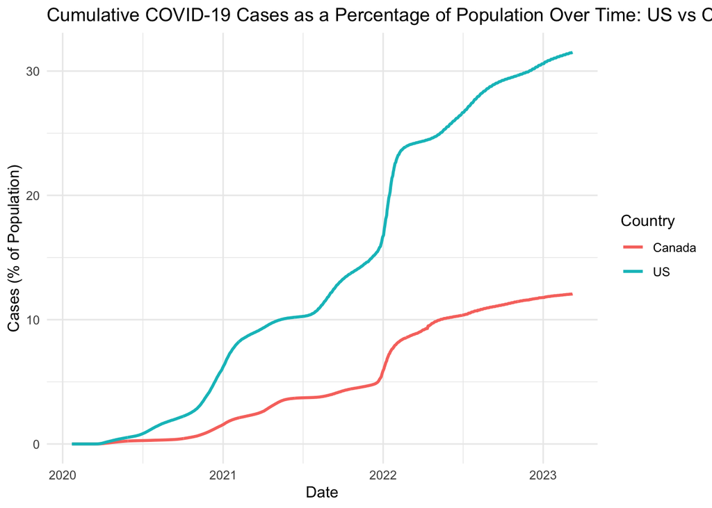

```r
ggplot(global_summary, aes(x = date, y = cases_percent, color = Country_Region)) +
  geom_line(linewidth = 1) +
  labs(
    title = "Cumulative COVID-19 Cases as a Percentage of Population Over Time: US vs Canada",
    x = "Date",
    y = "Cases (% of Population)",
    color = "Country"
  ) +
  theme_minimal()
```

## Cumulative COVID-19 Deaths as a Percentage of Population Over Time: US vs Canada

The deaths will also be plotted as a percentage of the total population over time for US and Canada.

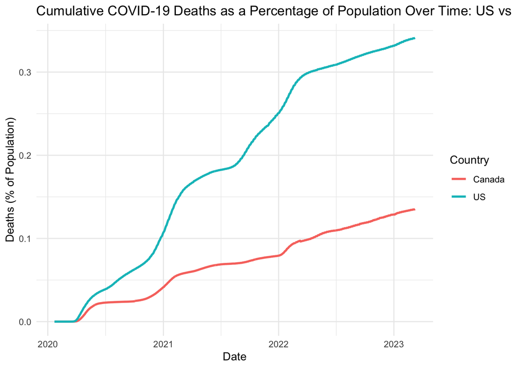

```r
ggplot(global_summary, aes(x = date, y = deaths_percent, color = Country_Region)) +
  geom_line(linewidth = 1) +
  labs(
    title = "Cumulative COVID-19 Deaths as a Percentage of Population Over Time: US vs Canada",
    x = "Date",
    y = "Deaths (% of Population)",
    color = "Country"
  ) +
  theme_minimal()
```

# **Data Modeling**

## Convert the Dates to a Numeric Format

First, a new column called “day_number” will be created in the global_summary table using the date column. The day_number column will be a numeric data type.

```r
global_summary <- global_summary %>%
mutate(day_number = as.numeric(date))
```

## Preparing Filtered Data for Linear Models

The US and Canada data will each be filtered into us_data and canada_data, respectively. This is to prepare the data before they are used for linear model creation.

```r
us_data <- global_summary %>% filter(Country_Region == "US")
canada_data <- global_summary %>% filter(Country_Region == "Canada")
```

## Creating the Four Linear Models

The four linear models will now be created. Two models will be created for US and Canada. Each country will have a model for the cases and deaths.

```r
us_cases_lm <- lm(cases_percent ~ day_number, data = us_data)
us_deaths_lm <- lm(deaths_percent ~ day_number, data = us_data)
canada_cases_lm <- lm(cases_percent ~ day_number, data = canada_data)
canada_deaths_lm <- lm(deaths_percent ~ day_number, data = canada_data)
```

## Plotting the Linear Models Against Actual Data

Each of the models will be plotted against the actual data to better visualize the model’s fit.

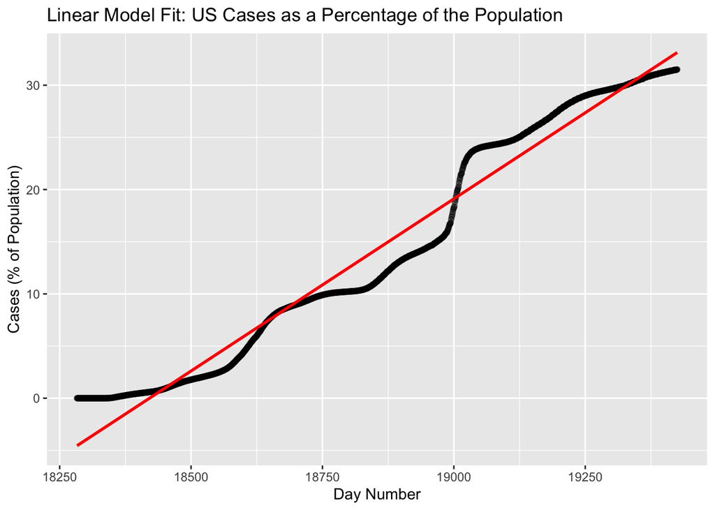

```r
ggplot(us_data, aes(x = day_number, y = cases_percent)) +
  geom_point(alpha = 0.5) +
  geom_smooth(method = "lm", se = FALSE, color = "red") +
  labs(title = "Linear Model Fit: US Cases as a Percentage of the Population",
       x = "Day Number", y = "Cases (% of Population)")
```

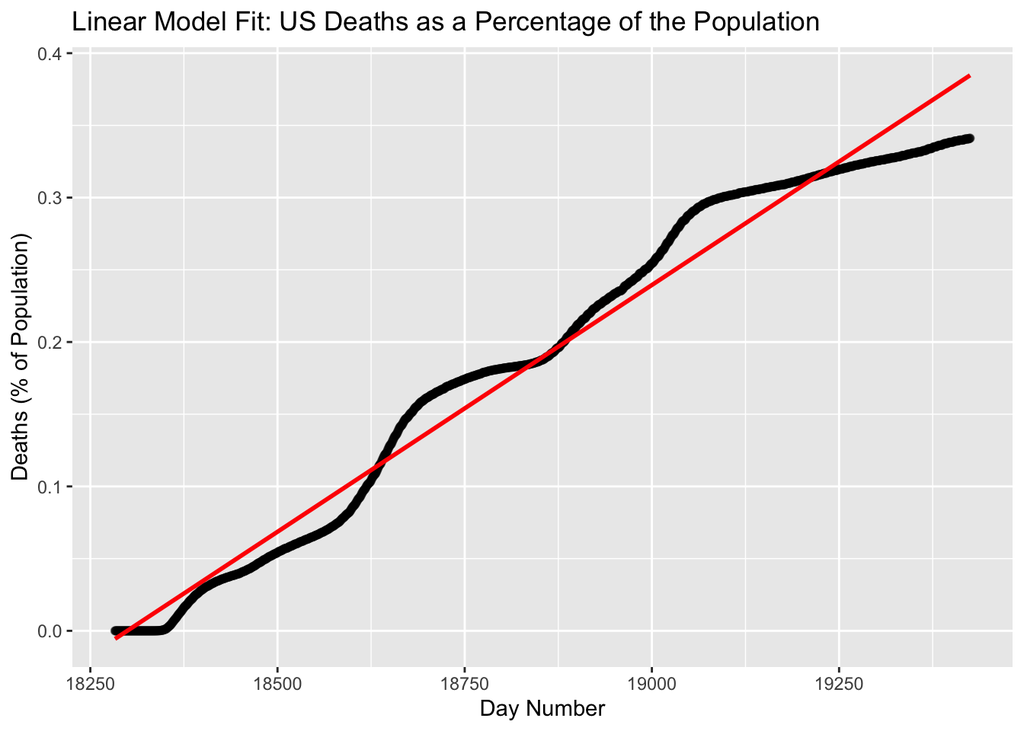

```r
ggplot(us_data, aes(x = day_number, y = deaths_percent)) +
  geom_point(alpha = 0.5) +
  geom_smooth(method = "lm", se = FALSE, color = "red") +
  labs(title = "Linear Model Fit: US Deaths as a Percentage of the Population",
       x = "Day Number", y = "Deaths (% of Population)")
```

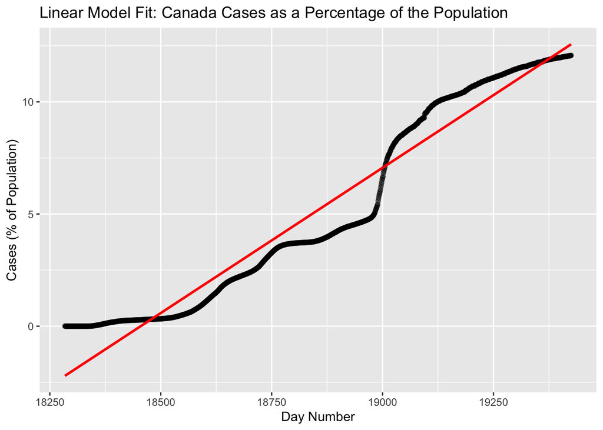

```r
ggplot(canada_data, aes(x = day_number, y = cases_percent)) +
  geom_point(alpha = 0.5) +
  geom_smooth(method = "lm", se = FALSE, color = "red") +
  labs(title = "Linear Model Fit: Canada Cases as a Percentage of the Population",
       x = "Day Number", y = "Cases (% of Population)")
```

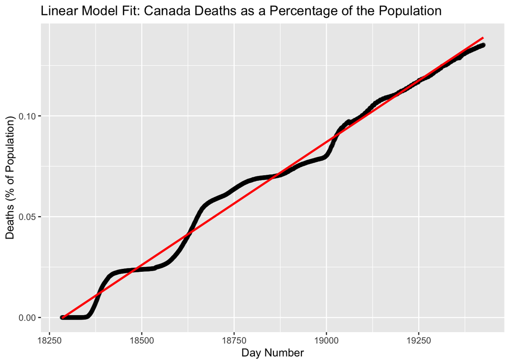

```r
ggplot(canada_data, aes(x = day_number, y = deaths_percent)) +
  geom_point(alpha = 0.5) +
  geom_smooth(method = "lm", se = FALSE, color = "red") +
  labs(title = "Linear Model Fit: Canada Deaths as a Percentage of the Population",
       x = "Day Number", y = "Deaths (% of Population)")
```

## Summary of the Linear Models

A summary of the linear models will be viewed to see the R-squared value and the statistical significance. Based on the R-squared values and the p-values, we can see that all the models have at least a 0.94 R-squared value (with Canada deaths model having the highest at 0.989) which means that they are all good fitting models with R-squared values all above 0.94. Furthermore, the p-values all indicate that the trends are all statistically significant.

```r
summary(us_cases_lm)
```

```
##
## Call:
## lm(formula = cases_percent ~ day_number, data = us_data)
##
## Residuals:
##    Min     1Q Median     3Q    Max
## -3.164 -1.578 -0.145  1.787  4.552
##
## Coefficients:
##               Estimate Std. Error t value Pr(>|t|)
## (Intercept) -6.079e+02  3.343e+00  -181.8   <2e-16 ***
## day_number   3.300e-02  1.773e-04   186.1   <2e-16 ***
## ---
## Signif. codes:  0 '***' 0.001 '**' 0.01 '*' 0.05 '.' 0.1 ' ' 1
##
## Residual standard error: 1.978 on 1141 degrees of freedom
## Multiple R-squared:  0.9681, Adjusted R-squared:  0.9681
## F-statistic: 3.464e+04 on 1 and 1141 DF,  p-value: < 2.2e-16
```

```r
summary(us_deaths_lm)
```

```
##
## Call:
## lm(formula = deaths_percent ~ day_number, data = us_data)
##
## Residuals:
##      Min       1Q   Median       3Q      Max
## -0.04360 -0.01351 -0.00029  0.01403  0.03276
##
## Coefficients:
##               Estimate Std. Error t value Pr(>|t|)
## (Intercept) -6.254e+00  3.056e-02  -204.6   <2e-16 ***
## day_number   3.418e-04  1.621e-06   210.9   <2e-16 ***
## ---
## Signif. codes:  0 '***' 0.001 '**' 0.01 '*' 0.05 '.' 0.1 ' ' 1
##
## Residual standard error: 0.01808 on 1141 degrees of freedom
## Multiple R-squared:  0.975,  Adjusted R-squared:  0.975
## F-statistic: 4.447e+04 on 1 and 1141 DF,  p-value: < 2.2e-16
```

```r
summary(canada_cases_lm)
```

```
##
## Call:
## lm(formula = cases_percent ~ day_number, data = canada_data)
##
## Residuals:
##     Min      1Q  Median      3Q     Max
## -1.8963 -0.7590 -0.0458  0.9220  2.2122
##
## Coefficients:
##               Estimate Std. Error t value Pr(>|t|)
## (Intercept) -2.391e+02  1.713e+00  -139.6   <2e-16 ***
## day_number   1.295e-02  9.084e-05   142.6   <2e-16 ***
## ---
## Signif. codes:  0 '***' 0.001 '**' 0.01 '*' 0.05 '.' 0.1 ' ' 1
##
## Residual standard error: 1.012 on 1140 degrees of freedom
## Multiple R-squared:  0.9469, Adjusted R-squared:  0.9469
## F-statistic: 2.034e+04 on 1 and 1140 DF,  p-value: < 2.2e-16
```

```r
summary(canada_deaths_lm)
```

```
##
## Call:
## lm(formula = deaths_percent ~ day_number, data = canada_data)
##
## Residuals:
##        Min         1Q     Median         3Q        Max
## -0.0076448 -0.0027753 -0.0003818  0.0026983  0.0088172
##
## Coefficients:
##               Estimate Std. Error t value Pr(>|t|)
## (Intercept) -2.231e+00  7.179e-03  -310.8   <2e-16 ***
## day_number   1.220e-04  3.807e-07   320.4   <2e-16 ***
## ---
## Signif. codes:  0 '***' 0.001 '**' 0.01 '*' 0.05 '.' 0.1 ' ' 1
##
## Residual standard error: 0.004242 on 1140 degrees of freedom
## Multiple R-squared:  0.989,  Adjusted R-squared:  0.989
## F-statistic: 1.027e+05 on 1 and 1140 DF,  p-value: < 2.2e-16
```

# **Data Analysis**

## Finding the Final Percentage of Cases and Deaths Per Country

The goal is the report the final impact of cases and deaths as of the most recently recorded date for US and Canada. Once the final percentages are obtained the differences between the two countries can be compared.

```r
global_summary %>%
  group_by(Country_Region) %>%
  filter(date == max(date)) %>%
  select(Country_Region, cases_percent, deaths_percent)
```

```
## # A tibble: 2 × 3
## # Groups:   Country_Region [2]
##   Country_Region cases_percent deaths_percent
##   <chr>                  <dbl>          <dbl>
## 1 Canada                  12.1          0.135
## 2 US                      31.5          0.341
```

From this analysis, it’s evident that the US had around (31.5/12.1) = 2.6 times more cases than Canada and (0.341/0.135) = 2.5 more deaths than Canada. Therefore for both cases and deaths US had a greater percentage of its population for the most recently recorded date than Canada.

# **Conclusion**

## Summary of Key Findings

There are three main areas that are going to be summarized between the two countries: the final case/death percentages, comparative trends over time, and the model results.

1. Final Case/Death Percentages

It appears that US and Canada had a final case percentage of 31.5% and 12.1%, respectively. US and Canada had a final death percentage of 0.341% and 0.135%. In conclusion, at the most presently recorded date US had around 2.5 times more cases and deaths.

2. Comparative Trends Over Time

Judging from the two line graphs created it looks like both US and Canada had their cases and deaths rising in a somewhat linear fashion. There did, however, appear to be a surge in 2022 for cases. This could be due to less strict lock down conditions and a gradual reopening of the countries. This should be further investigated.

3. Model Results

The four linear models created all had statistically significant p-values and all had at least a 94% R-squared value which indicated a good fit.

## Sources of Bias

Finally, a few sources of bias will be addressed: testing availability and reporting bias, under reporting of deaths, and population demographics.

1. Testing Availability and Reporting Bias

Early on in the pandemic, testing was limited and many initial cases were likely missed, especially the asymptomatic cases. US and Canada may have also had different testing strategies, so the testing strategy may have had more impact on the reported cases numbers than initially thought. This will underestimate total infections especially in early 2020.

2. Under Reporting of Deaths

Since US and Canada are not the same country they may vary a bit in their definitions of COVID-19 related death. They would have to have the exact same definition to ensure they are measuring the deaths in the exact same way without bias. This could lead to unreported or wrongly classified deaths.

3. Population Demographics

This report considers cases and deaths as a percentage of the total population, but doesn’t account for factors such as age distribution, urban density, and health care system capacity. These factors could make a country’s results look worse or better despite having similar policies. For example, older populations usually have higher death rates, and no analysis was done on the percentage of the older population in each country.